# 2019 Electronic Sales Exploratory Data Analysis

Kevin Banh

2/22/2022

# Introduction

We’ll be looking at sales data for electronics for a store during the entirety of 2019. Some exploratory data analysis will be done to gain some insights on the data.

The source of the data is https://github.com/KeithGalli/Pandas-Data-Science-Tasks/tree/master/SalesAnalysis/Sales_Data

# Libraries

```r
# Data visualization
library(ggplot2)
library(RColorBrewer)
library(ggtext)
library(scales)

# Data manipulation
library(tidyverse)
library(stringr)
library(reshape)
```

# Data processing

## Merging 12 months of data

```r
months <- c("January", "February", "March", "April", "May", "June",
            "July", "August", "September", "October", "November", "December")

# Create an empty dataframe so we can append each month's data to
df <- data.frame()

for(i in months){
  # Create a string for the data name of each month
  data_name <- paste0("Sales_", i,"_2019.csv")
  curr_df <- read.csv(data_name)

  # Append to our dataframe
  df <- rbind(df, curr_df)
}
```

## Data cleaning

```r
glimpse(df)
```

```
## Rows: 186,850
## Columns: 6
## $ Order.ID         <chr> "141234", "141235", "141236", "141237", "141238", "14~
## $ Product          <chr> "iPhone", "Lightning Charging Cable", "Wired Headphon~
## $ Quantity.Ordered <chr> "1", "1", "2", "1", "1", "1", "1", "1", "1", "1", "1"~
## $ Price.Each       <chr> "700", "14.95", "11.99", "149.99", "11.99", "2.99", "~
## $ Order.Date       <chr> "01/22/19 21:25", "01/28/19 14:15", "01/17/19 13:33",~
## $ Purchase.Address <chr> "944 Walnut St, Boston, MA 02215", "185 Maple St, Por~
```

```r
df <- df %>%
  mutate(Month = substr(Order.Date, 1, 2), # Extract month from date
         Month = as.integer(Month), # Convert to integer
         Price.Each = as.double(Price.Each),
         Quantity.Ordered = as.integer(Quantity.Ordered),
         Time = str_sub(Order.Date, -5, -4),
         Time = as.integer(Time),
         Order.ID = as.integer(Order.ID),
         Sales = Price.Each*Quantity.Ordered,
         State = str_sub(Purchase.Address, -8, -7) # Get state portion of address
          )
glimpse(df)
```

```
## Rows: 186,850
## Columns: 10
## $ Order.ID         <int> 141234, 141235, 141236, 141237, 141238, 141239, 14124~
## $ Product          <chr> "iPhone", "Lightning Charging Cable", "Wired Headphon~
## $ Quantity.Ordered <int> 1, 1, 2, 1, 1, 1, 1, 1, 1, 1, 1, 1, 3, 1, 1, 1, 1, 1,~
## $ Price.Each       <dbl> 700.00, 14.95, 11.99, 149.99, 11.99, 2.99, 389.99, 11~
## $ Order.Date       <chr> "01/22/19 21:25", "01/28/19 14:15", "01/17/19 13:33",~
## $ Purchase.Address <chr> "944 Walnut St, Boston, MA 02215", "185 Maple St, Por~
## $ Month            <int> 1, 1, 1, 1, 1, 1, 1, 1, 1, 1, 1, 1, 1, 1, 1, 1, 1, 1,~
## $ Time             <int> 21, 14, 13, 20, 11, 20, 12, 12, 10, 21, 11, 10, 18, 1~
## $ Sales            <dbl> 700.00, 14.95, 23.98, 149.99, 11.99, 2.99, 389.99, 11~
## $ State            <chr> "MA", "OR", "CA", "CA", "TX", "CA", "CA", "CA", "CA",~
```

Looks good! Now, let’s try to handle any duplicate records.

```r
# Find duplicate records
df %>%
  group_by_all() %>%
  filter(n() > 1) %>%
  ungroup()
```

```
## # A tibble: 1,428 x 10
##    Order.ID Product      Quantity.Ordered Price.Each Order.Date Purchase.Address
##       <int> <chr>                   <int>      <dbl> <chr>      <chr>
##  1       NA ""                         NA      NA    ""         ""
##  2       NA ""                         NA      NA    ""         ""
##  3       NA ""                         NA      NA    ""         ""
##  4   142071 "AA Batteri~                1       3.84 "01/17/19~ "131 2nd St, Bo~
##  5   142071 "AA Batteri~                1       3.84 "01/17/19~ "131 2nd St, Bo~
##  6       NA ""                         NA      NA    ""         ""
##  7       NA "Product"                  NA      NA    "Order Da~ "Purchase Addre~
##  8       NA "Product"                  NA      NA    "Order Da~ "Purchase Addre~
##  9       NA "Product"                  NA      NA    "Order Da~ "Purchase Addre~
## 10       NA ""                         NA      NA    ""         ""
## # ... with 1,418 more rows, and 4 more variables: Month <int>, Time <int>,
## #   Sales <dbl>, State <chr>
```

```r
# There's 1428 duplicate rows so let's just keep the distinct rows
df <- df %>%
  distinct()

# Check for consistency how many rows are removed in case we messed up somewhere
dim(df)
```

```
## [1] 185688     10
```

```r
# Let's test again to see if it worked
df %>%
  group_by_all() %>%
  filter(n() > 1) %>%
  ungroup()
```

```
## # A tibble: 0 x 10
## # ... with 10 variables: Order.ID <int>, Product <chr>, Quantity.Ordered <int>,
## #   Price.Each <dbl>, Order.Date <chr>, Purchase.Address <chr>, Month <int>,
## #   Time <int>, Sales <dbl>, State <chr>
```

We get an empty table meaning there are no more duplicate records.

Let’s tackle any null values that are not spread across a whole record

```r
sum(is.na(df))
```

```
## [1] 12
```

```r
for(i in 1:dim(df)[2]){
  count = 0
  for(j in 1:dim(df)[1]){
    if(is.na(df[j,i])){
      count = count + 1
    }
  }
  print(paste0(names(df)[i], ": ", count))
}
```

```
## [1] "Order.ID: 2"
## [1] "Product: 0"
## [1] "Quantity.Ordered: 2"
## [1] "Price.Each: 2"
## [1] "Order.Date: 0"
## [1] "Purchase.Address: 0"
## [1] "Month: 2"
## [1] "Time: 2"
## [1] "Sales: 2"
## [1] "State: 0"
```

Since we have **very few** NA values, we’ll just delete them entirely especially since we cannot perform any kind of imputation on the fields that contain them.

```r
df <- na.omit(df)
```

# Exploratory date analysis

```r
plot_settings <- function(x){
  # x is a ggplot object

  x <- x +
      theme(legend.position = "none",
      axis.ticks.y = element_blank(),
      axis.ticks.x = element_blank(),
      panel.background = element_blank(),
      axis.title.x = element_text(hjust = 0),
      axis.title.y = element_text(hjust = 1),
      axis.title = element_text(color = "#808080"),
      plot.title = element_markdown(size = 17)) +
      scale_y_continuous(labels = comma) +
      scale_fill_manual(values = c("royalblue4", "#808080"))  +
      scale_fill_manual(values = c("royalblue4", "#808080"))
  return(x)
}
```

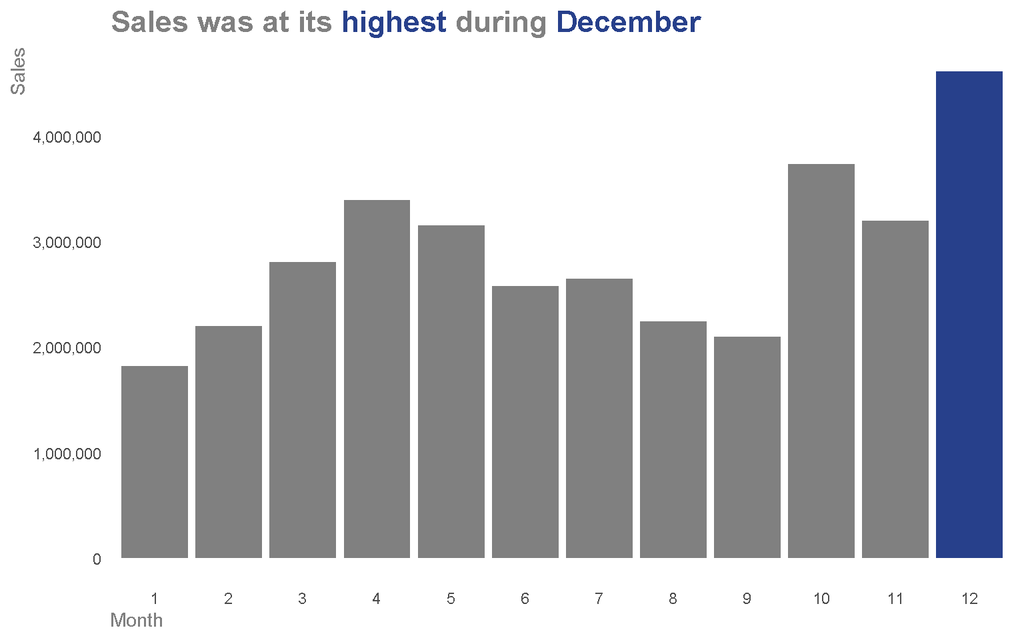

```r
g <- df %>%
  ggplot(aes(x = factor(Month), y = Sales, fill = factor(ifelse(Month == "12", "highlighted", "normal")))) +
  geom_bar(stat = "identity") +
  xlab("Month") +
  labs(title = "<b style='color:#808080'>Sales was at its
    <b style='color:#27408b'>highest
    <b style='color:#808080'>during
    <b style='color:#27408b'>December</b>") +
  scale_fill_manual(values = c("royalblue4", "#808080"))

plot_settings(g)
```

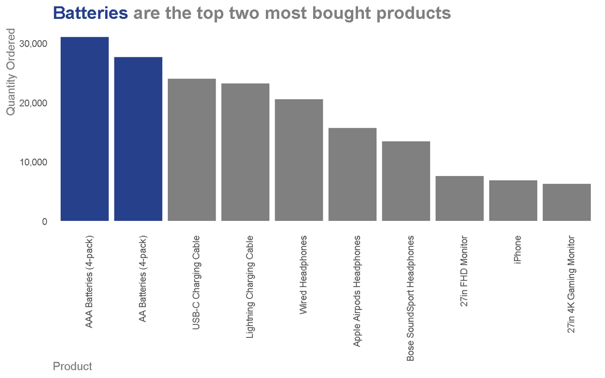

```r
g2 <- df %>%
  group_by(Product) %>%
  summarize(Quantity.Ordered = sum(Quantity.Ordered)) %>%
  arrange(desc(Quantity.Ordered)) %>%
  top_n(10) %>%
  ggplot(aes(x = factor(Product, levels = Product), y = Quantity.Ordered,
             fill = ifelse(Product == "AAA Batteries (4-pack)", "highlighted",
                           ifelse(Product == "AA Batteries (4-pack)", "highlighted",
                                  "normal")))) +
    geom_bar(stat = "identity") +
    ylab("Quantity Ordered") +
    xlab("Product") +
    theme(axis.text.x = element_text(angle = 90, hjust = 1)) +
    labs(title = "<b style='color:#27408b'>Batteries
         <b style='color:#808080'>are the top two most bought products</b>") +
  scale_fill_manual(values = c("royalblue4", "#808080"))
plot_settings(g2)
```

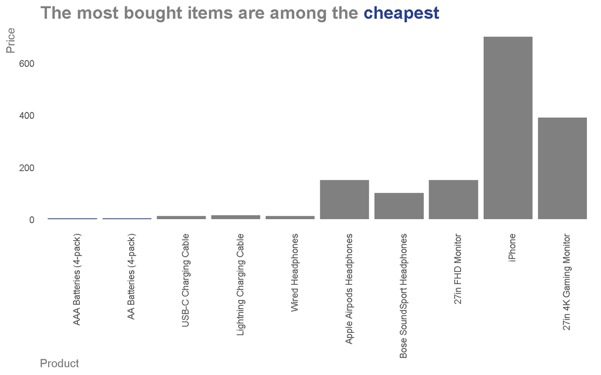

```r
g3 <- df %>%
  group_by(Product, Price.Each) %>%
  summarize(Quantity.Ordered = sum(Quantity.Ordered)) %>%
  arrange(desc(Quantity.Ordered)) %>%
  head(10) %>%
  ggplot(aes(x = factor(Product, levels = Product), y = Price.Each,
             fill = ifelse(Product == "AAA Batteries (4-pack)", "highlighted",
                           ifelse(Product == "AA Batteries (4-pack)", "highlighted",
                                  "normal")))) +
    geom_bar(stat = "identity") +
    ylab("Price") +
    xlab("Product") +
    theme(axis.text.x = element_text(angle = 90, hjust = 1)) +
    labs(title = "<b style='color:#808080'>The most bought items are among the
         <b style='color:#27408b'>cheapest</b>") +
  scale_fill_manual(values = c("royalblue4", "#808080"))
plot_settings(g3)
```

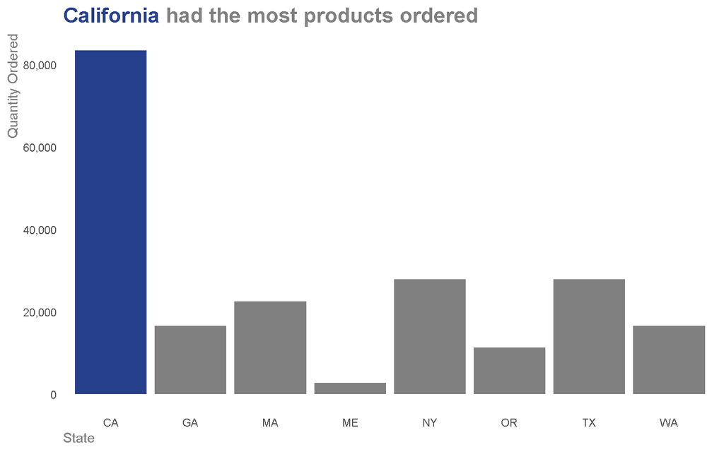

```r
g4 <- df %>%
  ggplot(aes(x = State, y = Quantity.Ordered,
             fill = ifelse(State == "CA", "highlighted", "normal"))) +
  geom_bar(stat = "Identity") +
  ylab("Quantity Ordered") +
  labs(title = "<b style='color:#27408b'>California
       <b style='color:#808080'>had the most products ordered</b>") +
  scale_fill_manual(values = c("royalblue4", "#808080"))
plot_settings(g4)
```

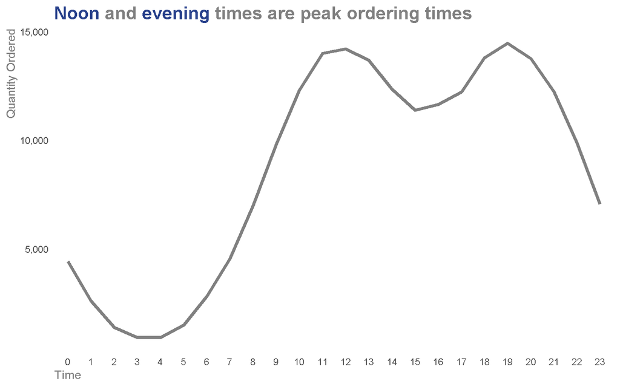

```r
g5 <- df %>%
  group_by(Time) %>%
  summarize(Quantity.Ordered = sum(Quantity.Ordered)) %>%
  ggplot(aes(x = factor(Time, levels = Time), y = Quantity.Ordered)) +
  geom_smooth(method = "lm", formula = y ~ poly(x, 3), se = FALSE) +
  geom_line(aes(group = 1), color = "#808080", size = 1.5) +
  xlab("Time") +
  ylab("Quantity Ordered") +
  labs(title = "<b style='color:#27408b'>Noon
       <b style='color:#808080'>and
       <b style='color:#27408b'>evening
       <b style='color:#808080'>times are peak ordering times</b>")
plot_settings(g5)
```

# Conclusion

Knowing the answers to these will help the business better target their consumers. For example, they should try focusing on a wide-range of products that have a low price and are useful to a wide range of audiences. AAA/AA batteries were the most bought items and were among the cheapest as well. Furthermore, they could target their California consumers more since they make up a vast chunk of the products bought.